# 9. Non-parametric statistics - Kruskal Wallis

Author

Lieven Clement

Published

Invalid Date

# 1 Vergelijking van $g$ groepen

- $F$-test uitbreiden van een eenrichtings-ANOVA naar niet-parametrische alternatieven.

# 2 DMH Voorbeeld

Beoordeel de genotoxiciteit van 1,2-dimethylhydrazine dihydrochloride (EU richtlijn)

- 24 rats
- vier groepen met dagelijkse DMH dosis
  - controle
  - laag
  - medium
  - hoog
- Genotoxiciteit in de lever met behulp van een comet assay op 150 levercellen per rat.
- Zijn er verschillen in DNA-schade als gevolg van de DMH-dosis?

## 2.1 Comet Assay:

- Visualiseer DNA-strengbreuken
- Lengte komeetstaart is een proxy voor strandbreuken.

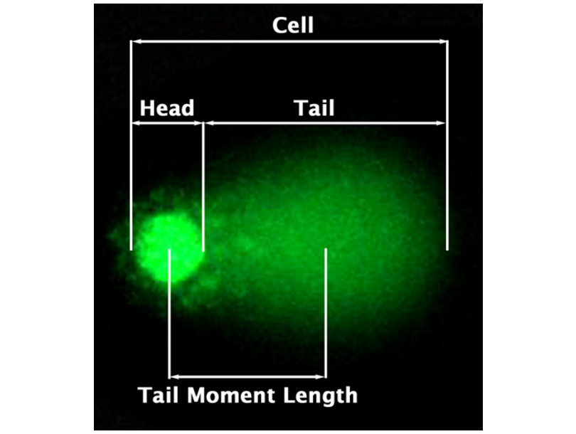

Comet assay

```r
dna <- read_delim("https://raw.githubusercontent.com/statOmics/sbc/master/data/dna.txt",delim=" ")
dna$dose <- as.factor(dna$dose)
dna
```

```
# A tibble: 24 × 3
   id    length dose
   <chr>  <dbl> <fct>
 1 Rat1    19.3 0
 2 Rat2    18.9 0
 3 Rat3    18.6 0
 4 Rat4    19.0 0
 5 Rat5    17.1 0
 6 Rat6    18.8 0
 7 Rat7    55.4 1.25
 8 Rat8    59.2 1.25
 9 Rat9    59.1 1.25
10 Rat10   52.1 1.25
# ℹ 14 more rows
```

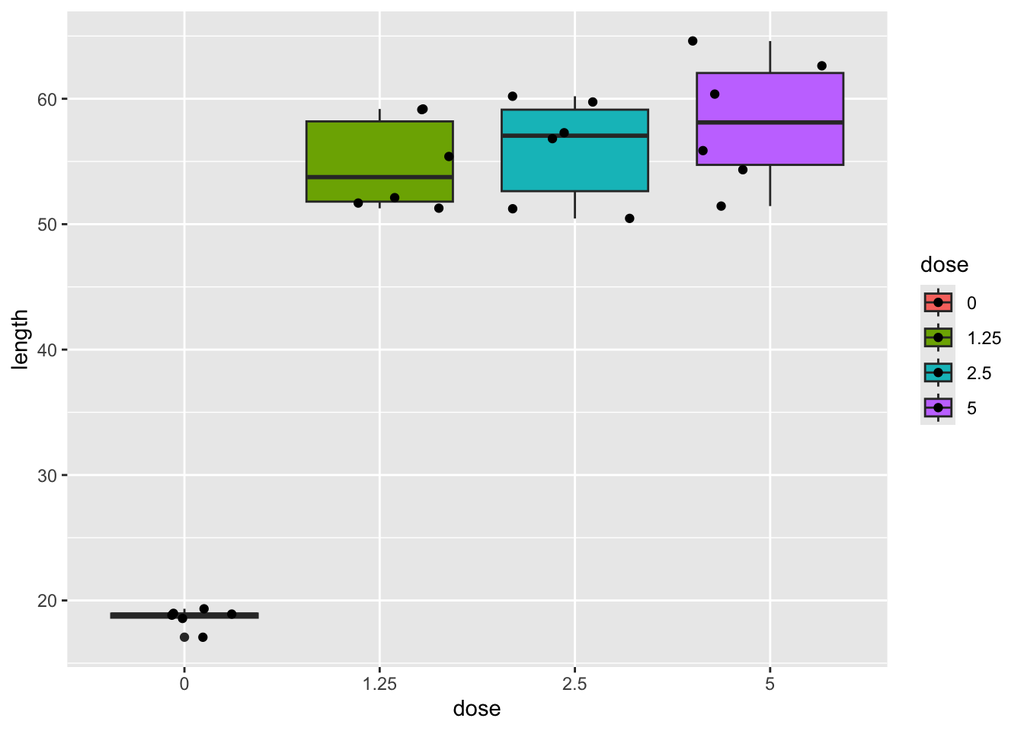

```r
dna |>
  ggplot(aes(x=dose,y=length,fill=dose))+
  geom_boxplot() +
  geom_point(position="jitter")
```

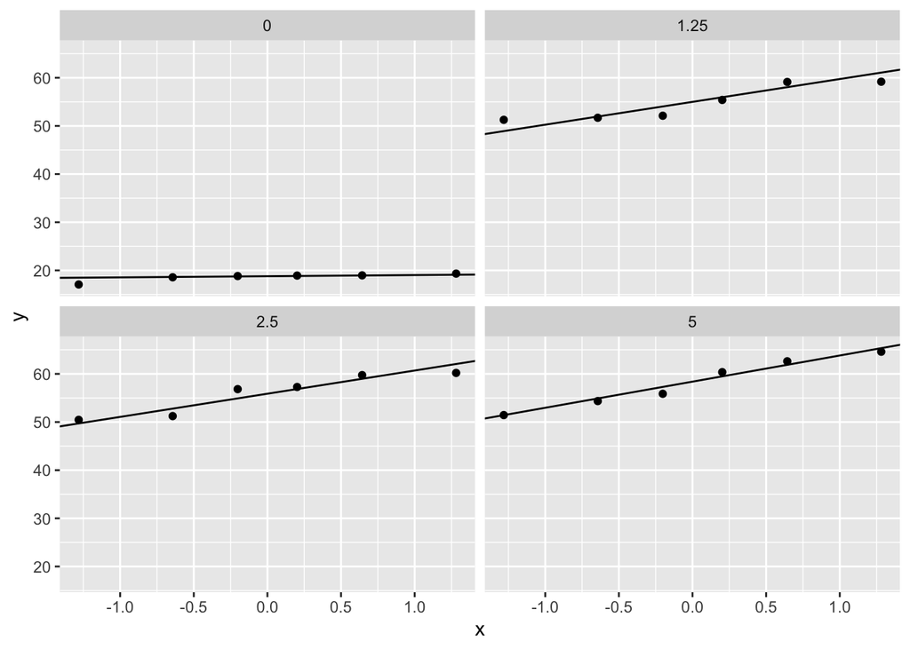

```r
dna |>
  ggplot(aes(sample=length)) +
  geom_qq() +
  geom_qq_line() +
  facet_wrap(~dose)
```

- Sterke indicatie dat gegevens in de controlegroep een lagere variantie hebben.
- 6 observaties per groep zijn te weinig om de aannames te controleren

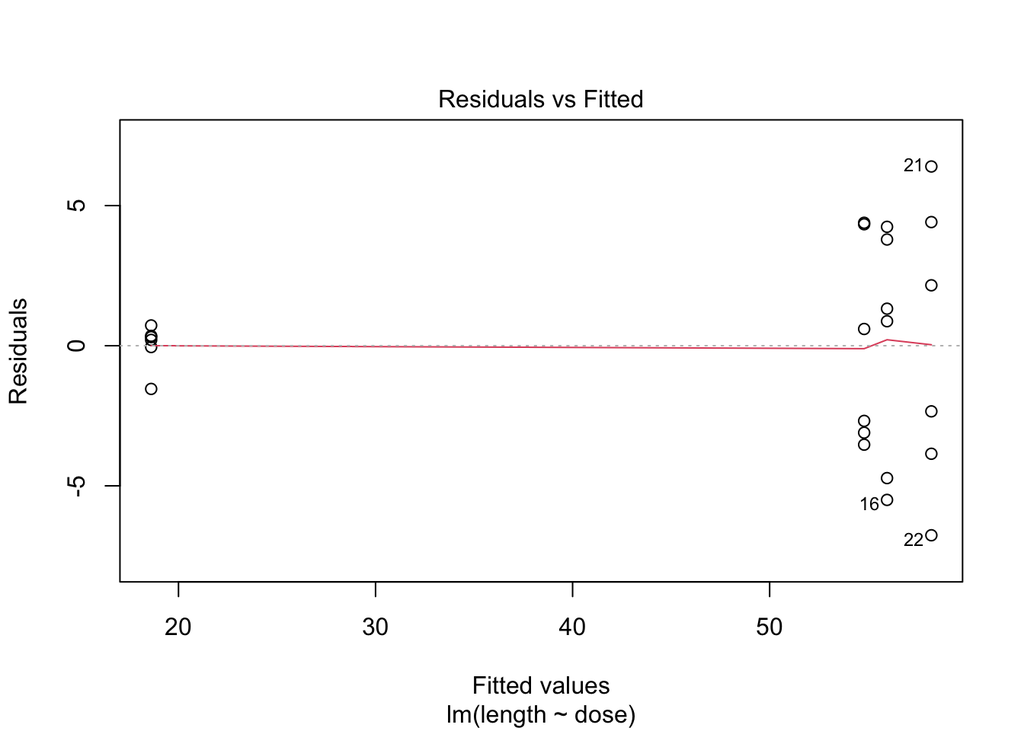

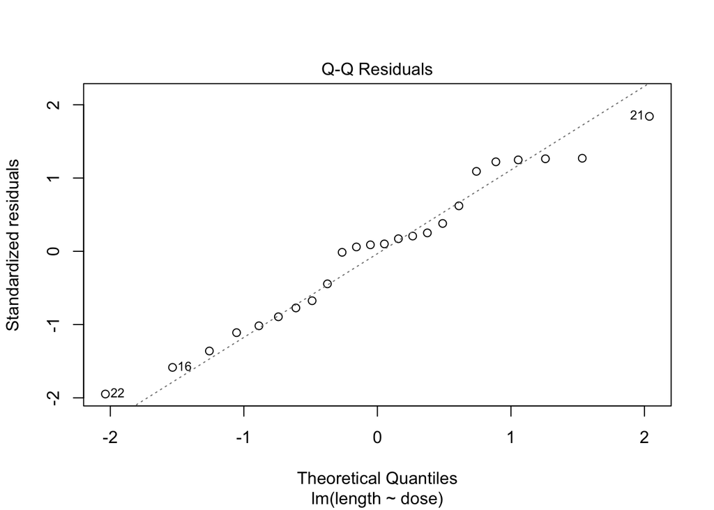

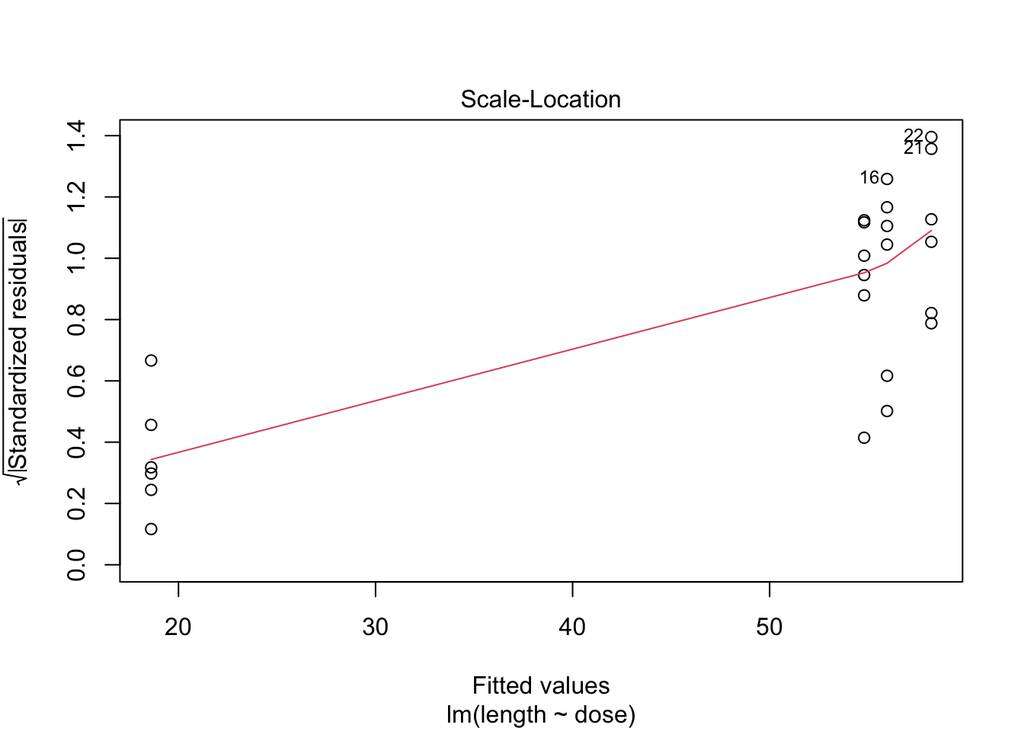

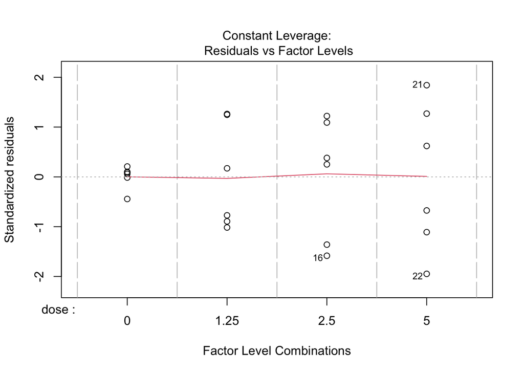

```r
plot(lm(length~dose,data=dna))
```